# pacu: Precision Agriculture Computational Utilities - Satellite data

Caio dos Santos & Fernando Miguez

2025-11-18

# Specific vignettes

1. Satellite data
2. Weather data
3. Yield monitor data
4. Frequently asked questions

# Satellite data

## Interacting with the OData API

### Setting up your credentials

The first step is to register the [Data Space](https://dataspace.copernicus.eu/) credentials to the R environment using *pa_intialize_dataspace()*

```r
un <- 'my-username'
pw <- 'my-password'
pa_initialize_dataspace(username = un, password = pw)
```

### Browsing the Data Space catalog

Let us define our area of interest. In this example, we are interested in a field in Ames, Iowa, U.S.

```r
extd.dir <- system.file("extdata", package = "pacu")
area.of.interest <- sf::st_read(file.path(extd.dir, 'cobs_a_aoi.shp'), quiet = TRUE)
```

Now, we can browse the Data Space catalog for images that meet our requirements. We can specify these requirements in by passing arguments to the **pa_browse_dataspace()** function. The function allows us to filter the satellite image using information such as dates, cloud coverage, and satellite platform. In this case, we are interested in images captured by Sentinel 2, with a maximum of 50% of cloud coverage, and in the year of 2023.

```r
available.images <- pa_browse_dataspace(aoi = area.of.interest,
                                        max.cloud.cover = 50,
                                        start.date = '2023-01-01',
                                        end.date = '2023-12-31',
                                        collection.name = 'SENTINEL-2')
```

Each entry in the data frame returned by the function is a satellite image available to be downloaded from Data Space. In this case, we can see that there are 69 images the meet our requirements.

```r
available.images
```

```
## Search parameters
## Start date: 2023-01-01
## End date: 2023-12-31
## Max. cloud cover: 50%
## Collection name:  SENTINEL-2
##
## Results
## Total:  69
## Online:  69
```

Using the “summary” function, we can extract the number of available images for every month in the data set.

```r
summary(available.images)
```

```
## ------------------
## Year  Month  Count
## ---   ---    ---
## 2023  1      4
## 2023  2      6
## 2023  3      4
## 2023  4      6
## 2023  5      7
## 2023  6      6
## 2023  7      8
## 2023  8      7
## 2023  9      6
## 2023  10     5
## 2023  11     7
## 2023  12     3
## ------------------
## Total    69
```

### Downloading satellite images from Data Space

```r
out.dir <- tempdir()
available.images <- available.images[32:33, ]
pa_download_dataspace(x = available.images,
                      dir.path = out.dir,
                      aoi = area.of.interest,
                      verbose = FALSE)
```

### Visualizing downloaded images

Now that we have downloaded the data, we might be interested in looking at RGB images.

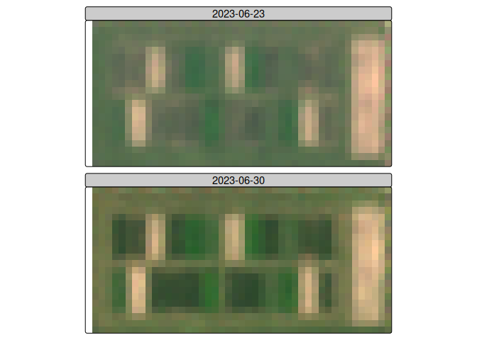

```r
s2.files <- list.files(out.dir, '\\.zip', full.names = TRUE)
rgb.img <- pa_get_rgb(s2.files,
                      aoi = area.of.interest,
                      verbose = FALSE)

pa_plot(rgb.img)
```

Similarly, we might be interested in NDVI or NDRE…

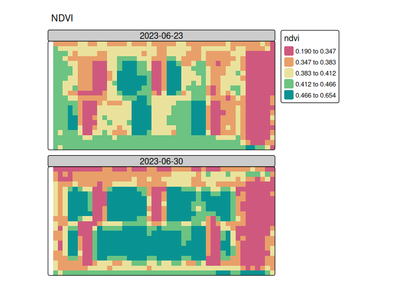

```r
ndvi.img <- pa_compute_vi(s2.files,
                          vi = 'ndvi',
                          aoi = area.of.interest,
                          verbose = FALSE)

ndre.img <- pa_compute_vi(s2.files,
                          vi = 'ndre',
                          aoi = area.of.interest,
                          verbose = FALSE)

pa_plot(ndvi.img, main = 'NDVI')
```

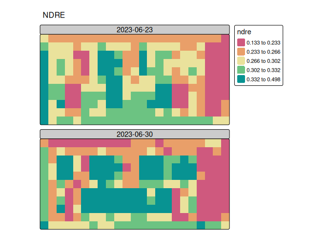

```r
pa_plot(ndre.img, main = 'NDRE')
```

## Areal summary

Often, in precision agriculture applications, we are interested in a summary value per experimental unit to evaluate the effect of an applied treatment. This statistic is commonly the mean or median of the pixels within the polygon representing the research plot or the area of interest. To illustrate how that can be achieved within pacu, we can split our area of interest in four smaller areas and then compute and visualize summary statistics.

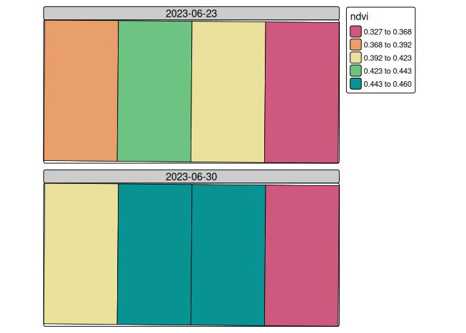

```r
split.aoi <- st_make_grid(area.of.interest, n = c(4, 1))
split.aoi <- st_as_sf(split.aoi)
split.aoi <- st_transform(split.aoi, st_crs(ndvi.img))
ndvi.mean <- summary(ndvi.img, by = split.aoi, fun = mean)
pa_plot(ndvi.mean)
```

## Interacting with the Copernicus Statistical API

The Data Space Statistics API allows users to download areal statistics calculated based on satellite images without having to download images. The Statistics API uses OAuth2.0 authentication with *client id* and *client secret*. To use the functions that interact with the Satistics API, you will need to [register an OAuth client](https://documentation.dataspace.copernicus.eu/APIs/SentinelHub/Overview/Authentication.html).

### Setting up your credentials

```r
cid <- 'my-client-id'
cs <- 'my-client-secret'
pa_initialize_oauth(client_id = cid, client_secret = cs)
```

### Requesting areal statistics

Now that your Oauth client credentials have been registered, you can request vegetation index statistics using the Statistics API. Let us request NDVI data for our area of interest.

```r
ndvi.statistics <- pa_get_vi_stats(aoi = area.of.interest,
                                   start.date = '2022-01-01',
                                   end.date = '2022-12-31',
                                   vegetation.index = 'ndvi',
                                   agg.time = 'P1D')
```

The *pa_plot()* function helps us visualize the data in a spatial context. Since we have requested the NDVI statistics for one polygon, it us to be expected that within each facet representing a date, there is only one color.

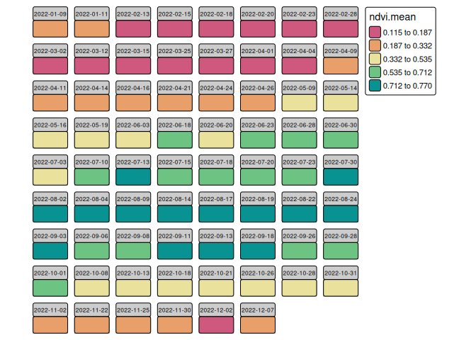

```r
pa_plot(ndvi.statistics)
```

Conversely, if we are more interested in examining the data in a time series format, we can specify the “plot.type”.

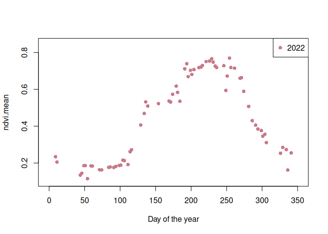

```r
pa_plot(ndvi.statistics,
        plot.type = 'timeseries')
```

We might also be interested in comparing the index value from different regions of the field. Let us split the previous field in four parts and retrieve NDVI individually for each section, so we can compare the results.

**note:** it is important to clarify that using the *by.feature* argument will send multiple requests to the Statistical API. The user should be mindful not to exceed their quota. Quotas and limitations can be found [here](https://documentation.dataspace.copernicus.eu/Quotas.html)

```r
ndvi.statistics.2 <- pa_get_vi_stats(aoi = split.aoi,
                                     start.date = '2022-01-01',
                                     end.date = '2022-05-01',
                                     vegetation.index = 'ndvi',
                                     agg.time = 'P1D',
                                     by.feature = TRUE)
```

Now, we can visualize the different parts of the field in a spatial and temporal context.

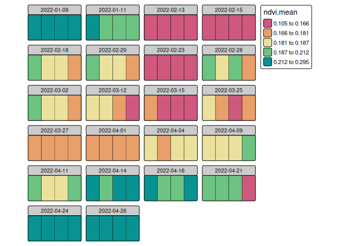

```r
pa_plot(ndvi.statistics.2)
```

Similarly to the previous example, we might be interested in examining the data in a time series format. In this case, we can specify the “by” argument and a different series will be plotted for each polygon “id”.

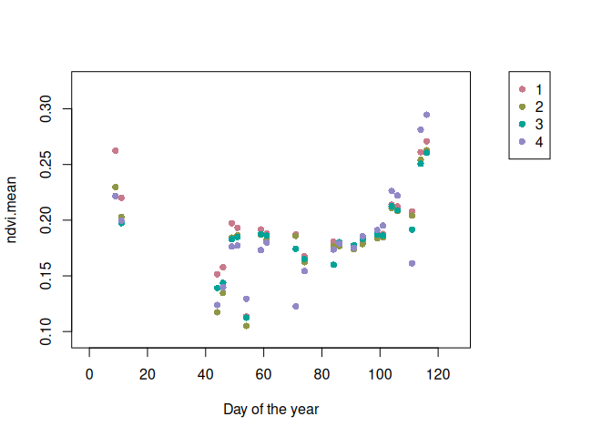

```r
pa_plot(ndvi.statistics.2,
        plot.type = 'timeseries',
        by = c('id'),
        legend.outside = TRUE)
```